# Plot density of imputations

Now for any variable, for one iteration nr. only.

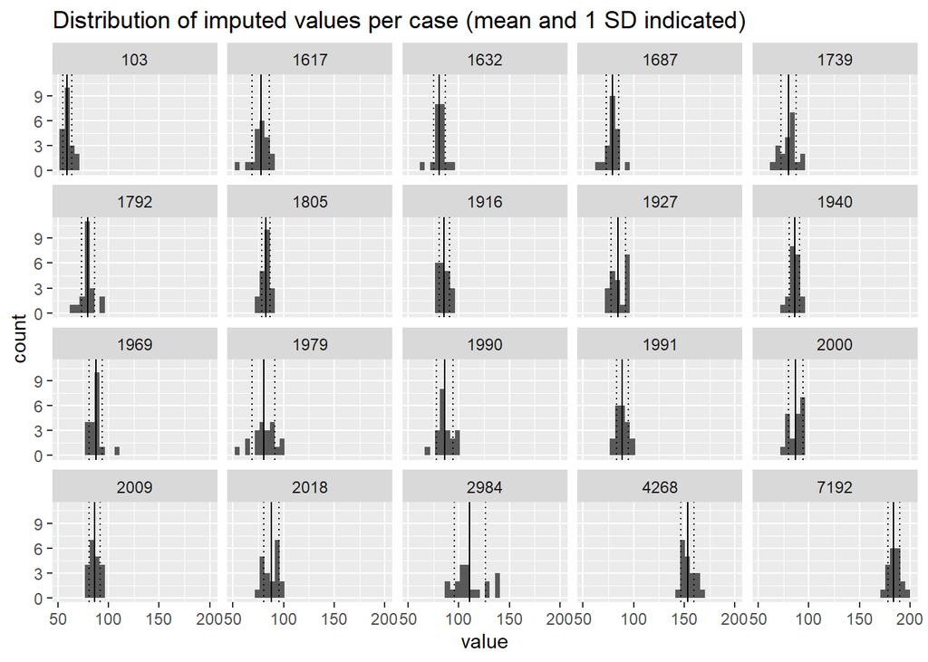

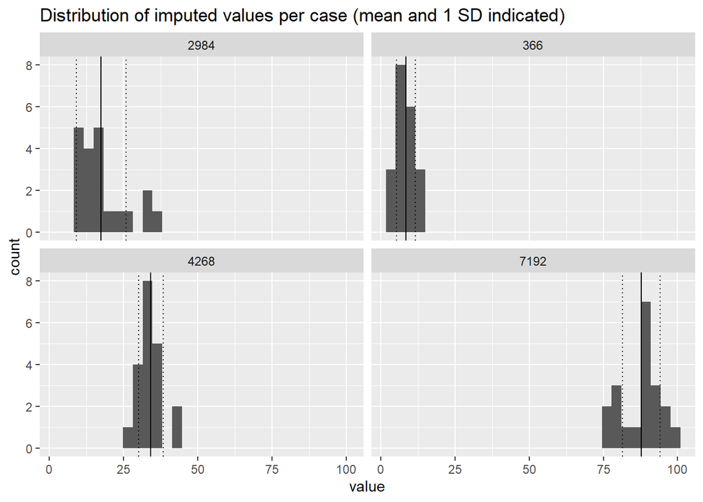

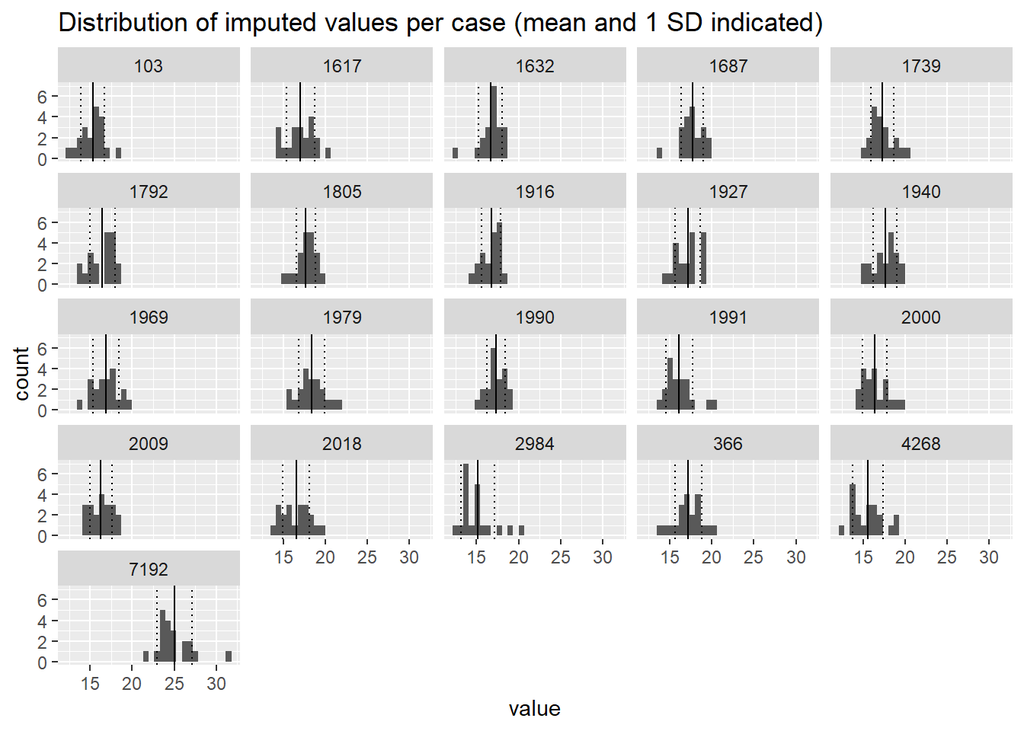

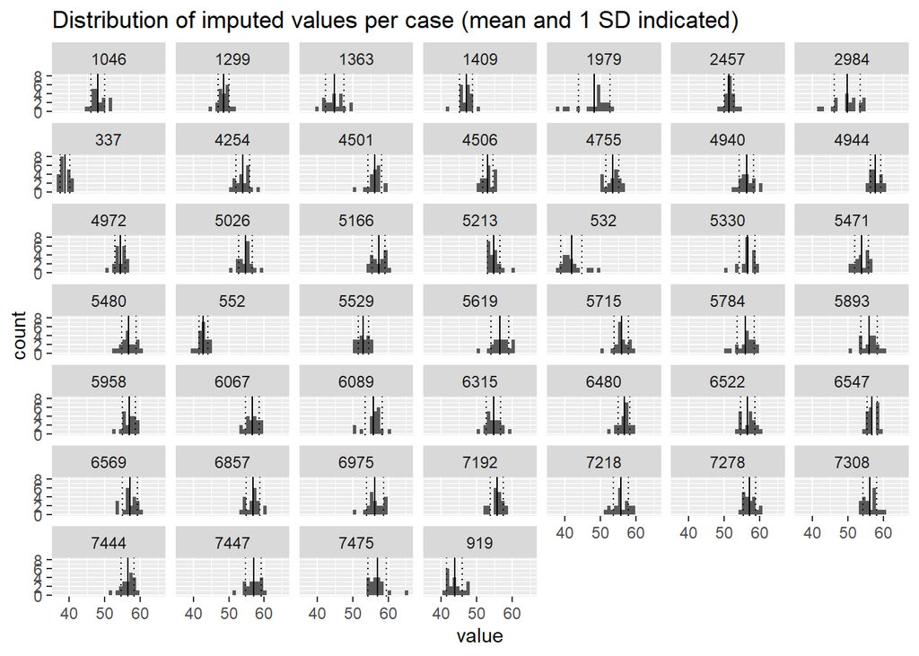

[figure not shown]

```r
# which vars?
# only numeric
num_vars <- dat %>% map(~{is.numeric(.x)})
dat <- dat[,num_vars==T]
# only with missings
nmis <- dat %>% map_dbl(~{is.na(.x) %>% sum()}) #%>% which(.>0) %>% names()
#nmis <- apply(is.na(dat), 2, sum)
vars <- names(nmis[nmis>0])

# extract imputed values, reshape data
imp_long <- mids[["imp"]][vars] %>% map( ~{
  mutate(., case = rownames(.)) %>%  tidyr::gather("imp", "value", 1:M)
  })

# compute mean and sd for each case
imp_descr <- imp_long %>% map( ~{
  group_by(., case) %>% summarise(mu = mean(value), sigma = sd(value), sd1 = mu+sigma, sd2 = mu-sigma)
})
# plot each case with mean and sd per variable
map2(imp_long, imp_descr, ~{
  ggplot(.x, aes(x = value)) +
    geom_histogram() +
    geom_vline(.y, mapping = aes(xintercept = mu)) +
    geom_vline(.y, mapping = aes(xintercept = sd1), linetype = "dotted") +
    geom_vline(.y, mapping = aes(xintercept = sd2), linetype = "dotted") +
    ggtitle("Distribution of imputed values per case (mean and 1 SD indicated)") +
    #xlab(.y) +
    facet_wrap( ~ case)
})
```

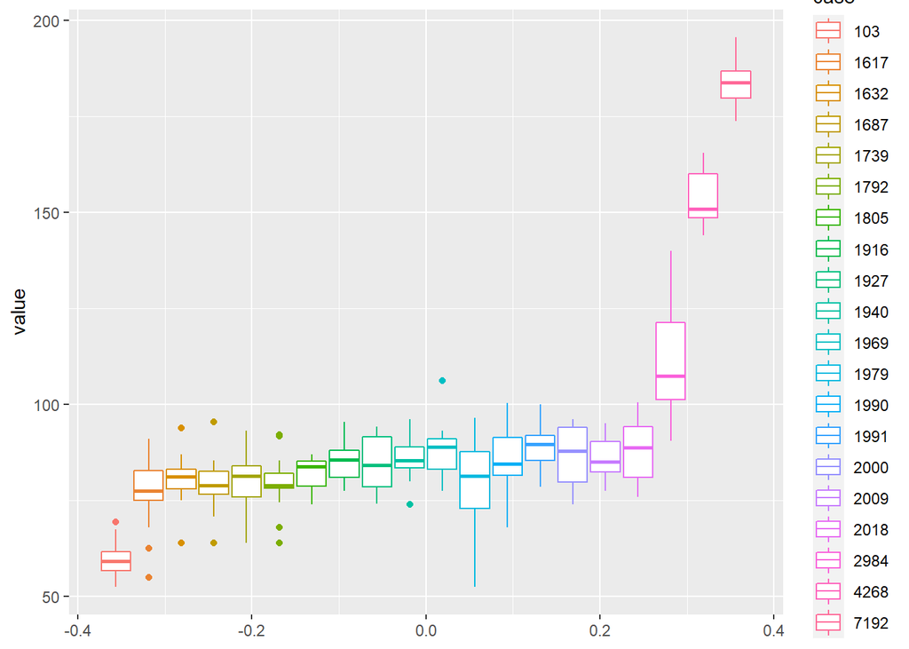

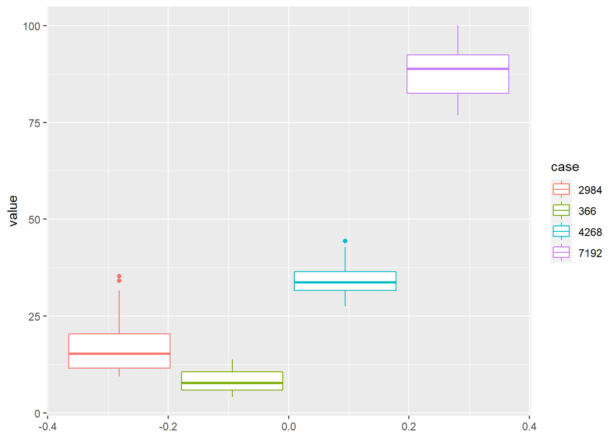

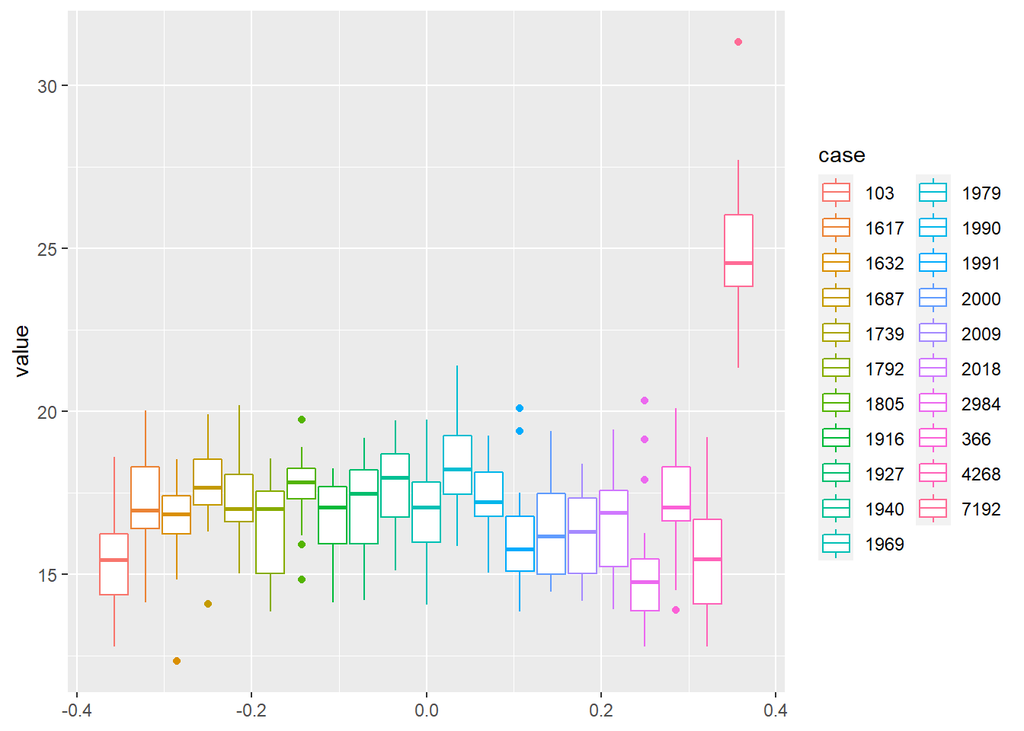

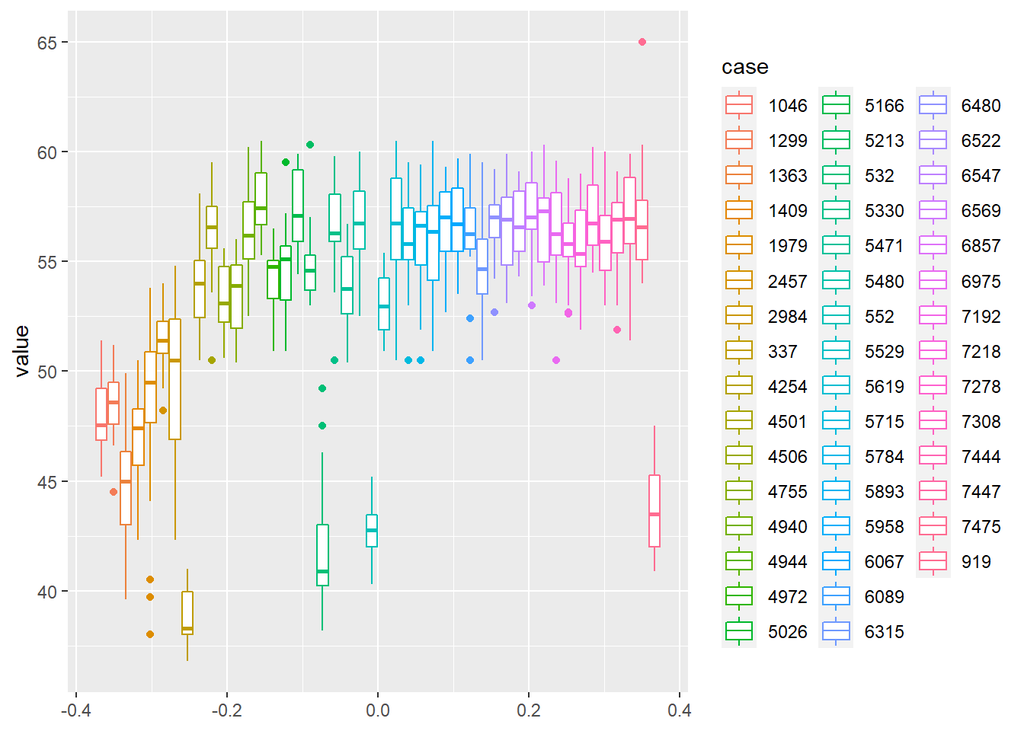

[figure not shown]

```r
map2(imp_long, imp_descr, ~{
  ggplot(.x, aes(y = value, color = case)) +
    geom_boxplot()
})
```

Boxplot is makkelijker te zien! Gelijke var en means. Na imp heb je 1 plotje dat een boxpl is van alle geimp. x as cases, y as variatie. sommige cases heel veel spreiding en andere heel weinig. Dat is leuk! miss op y en kolommen op x as, dan boxplot met wel/niet een bepaalde var missing.

Now try to automate this for all nrs of iterations